# COM747 Week 12: Teamwork Reflection and Process Mining

Seminar solutions

> **How to use this notebook.** Part A gives guidance and model answers for the group-work reflection questions (`Exercise - group work reflection.docx`). Part B completes the process mining tutorial with bupaR on the built-in `patients` event log, then goes further: performance, filtering, building your own log, and computing a process map’s transition probabilities by hand so you can see it is a first-order Markov model.

```r
# install.packages("bupaverse")   # installs bupaR, edeaR, processmapR, eventdataR, ...
library(bupaR)        # event log objects
library(edeaR)        # descriptive metrics: activity_frequency(), trace_length(), ...
library(processmapR)  # process_map(), trace_explorer()
library(eventdataR)   # example logs: patients, sepsis, traffic_fines
library(dplyr)
```

# Part A: Group work reflection

## A1. Benefits and challenges

| # | Benefits of team-based projects | Challenges of team-based projects |
| --- | --- | --- |
| 1 | A larger, more ambitious project than one person could complete | Coordinating timetables and deadlines |
| 2 | A mix of skills (R, statistics, writing, presenting) | Uneven contribution |
| 3 | Ideas are challenged, so errors are caught earlier | Competing ideas about data, methods and the story |
| 4 | Practice for industry: shared code, version control, reviews | Merging code and documents; version conflicts |
| 5 | Learning by explaining to each other | Communication across cultures, languages, online and in-person members |

## A2. Answering the interview questions: STAR

Structure each answer as **S**ituation, **T**ask, **A**ction, **R**esult, then a sentence of reflection. Make the Action the longest part, say “I” for what you did, and give a measurable result. Aim for 150–250 words (1–2 minutes spoken).

**Q1. Give an example of how you positively contributed to a group-based project.**

> *Situation:* In COM747 our team of four had six weeks to build and evaluate a model predicting student performance. *Task:* I was responsible for data preparation and for making sure the evaluation was sound. *Action:* I wrote the cleaning code in a shared R notebook and documented each step. When our first model scored 96%, I checked variable importance and found an ID column leaking the label. I showed the team the problem with a quick demo, removed the column, and set up 10-fold cross-validation with caret so all four models were compared on the same folds. *Result:* Our final accuracy was a realistic 72%, every number in the report was justified, and we submitted two days early. *Reflection:* I now check for leakage before trusting a good result.

**Q2. What are the benefits and challenges of working in a team, and how might you resolve competing ideas?**

> Teams bring more skills and ideas, and catch mistakes earlier; the challenge is turning disagreement into a decision without anyone feeling overruled. In our project two members wanted different datasets. I suggested we first agree criteria (fit to the brief, label quality, size, ethics), and each of us scored both datasets before meeting. We only discussed the scores where we disagreed. We chose the smaller, better-labelled dataset and used the larger one as an extension. We decided in one 30-minute meeting, and the extension became one of the strongest parts of the report. Agreeing criteria first keeps the discussion about the work, not the people.

## A3. Challenge, solution, role, reflection

| # | Challenge | Solution | Your role | What you would do differently |
| --- | --- | --- | --- | --- |
| 1 | Two members wanted different datasets | Agreed criteria, scored both, chose one | Proposed criteria, ran the comparison | Agree criteria in week 1 |
| 2 | Notebook versions overwrote each other | Git with one branch each and weekly merges | Set up the repository, taught others | Use version control from day one |
| 3 | A member stopped contributing | Private check-in; re-scoped their task | Had the conversation, re-planned | Weekly stand-ups to surface problems early |
| 4 | Accuracy looked too good | Found and removed a leaking ID column | Spotted it in variable importance | Review features for leakage before training |

**Ask:** If you’re comfortable, read your answers to a peer, friend or demonstrator and ask: “Could you tell what *I* did? Was there a number in the result?”

# Part B: Process mining with bupaR

## B1. The `patients` event log

```r
patients                     # an eventlog object: 500 cases, 2721 instances of 7 activities
```

```
## # Log of 5442 events consisting of:
## 7 traces
## 500 cases
## 2721 instances of 7 activities
## 7 resources
## Events occurred from 2017-01-02 11:41:53 until 2018-05-05 07:16:02
##
## # Variables were mapped as follows:
## Case identifier:     patient
## Activity identifier:     handling
## Resource identifier:     employee
## Activity instance identifier:    handling_id
## Timestamp:           time
## Lifecycle transition:        registration_type
##
## # A tibble: 5,442 x 7
##    handling   patient employee handling_id registration_type time
##    <fct>      <chr>   <fct>    <chr>       <fct>             <dttm>
##  1 Registrat~ 1       r1       1           start             2017-01-02 11:41:53
##  2 Registrat~ 2       r1       2           start             2017-01-02 11:41:53
##  3 Registrat~ 3       r1       3           start             2017-01-04 01:34:05
##  4 Registrat~ 4       r1       4           start             2017-01-04 01:34:04
##  5 Registrat~ 5       r1       5           start             2017-01-04 16:07:47
##  6 Registrat~ 6       r1       6           start             2017-01-04 16:07:47
##  7 Registrat~ 7       r1       7           start             2017-01-05 04:56:11
##  8 Registrat~ 8       r1       8           start             2017-01-05 04:56:11
##  9 Registrat~ 9       r1       9           start             2017-01-06 05:58:54
## 10 Registrat~ 10      r1       10          start             2017-01-06 05:58:54
## # i 5,432 more rows
## # i 1 more variable: .order <int>
```

```r
# ?patients                  # documentation for the dataset
mapping(patients)            # which column is the case, activity, timestamp, resource...
```

```
## Case identifier:     patient
## Activity identifier:     handling
## Resource identifier:     employee
## Activity instance identifier:    handling_id
## Timestamp:           time
## Lifecycle transition:        registration_type
```

```r
head(as.data.frame(patients), 8)
```

```
##       handling patient employee handling_id registration_type
## 1 Registration       1       r1           1             start
## 2 Registration       2       r1           2             start
## 3 Registration       3       r1           3             start
## 4 Registration       4       r1           4             start
## 5 Registration       5       r1           5             start
## 6 Registration       6       r1           6             start
## 7 Registration       7       r1           7             start
## 8 Registration       8       r1           8             start
##                  time .order
## 1 2017-01-02 11:41:53      1
## 2 2017-01-02 11:41:53      2
## 3 2017-01-04 01:34:05      3
## 4 2017-01-04 01:34:04      4
## 5 2017-01-04 16:07:47      5
## 6 2017-01-04 16:07:47      6
## 7 2017-01-05 04:56:11      7
## 8 2017-01-05 04:56:11      8
```

```r
c(cases = n_cases(patients), activities = n_activities(patients),
  instances = n_activity_instances(patients), events = n_events(patients))
```

```
##      cases activities  instances     events
##        500          7       2721       5442
```

Each activity instance has a *start* and a *complete* event, so there are 5,442 events for 2,721 activity instances.

## B2. Activity frequency and presence

```r
patients %>% activity_frequency("activity")
```

```
## # A tibble: 7 x 3
##   handling              absolute relative
##   <fct>                    <int>    <dbl>
## 1 Registration               500   0.184
## 2 Triage and Assessment      500   0.184
## 3 Discuss Results            495   0.182
## 4 Check-out                  492   0.181
## 5 X-Ray                      261   0.0959
## 6 Blood test                 237   0.0871
## 7 MRI SCAN                   236   0.0867
```

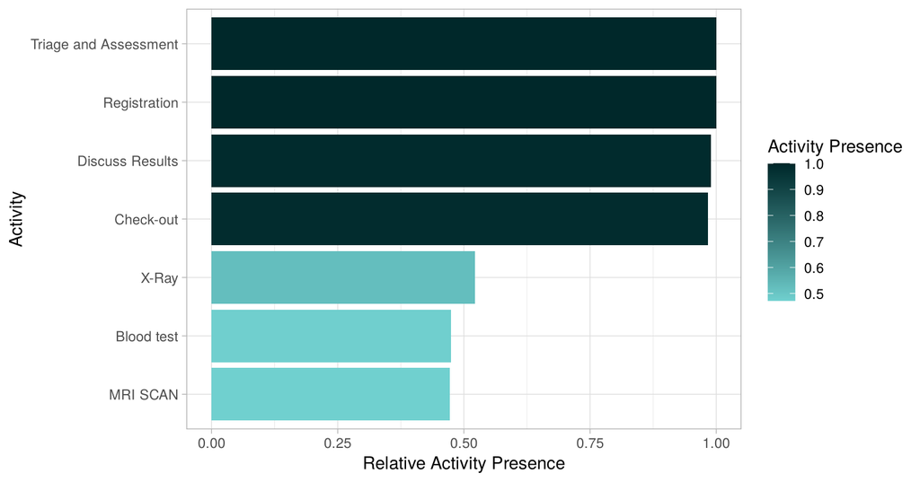

```r
patients %>% activity_presence() %>% plot()
```

Registration and Triage happen for every patient (100%); about half have an X-ray and half a blood test and MRI.

## B3. Trace length

```r
patients %>% trace_length("log")
```

```
## # A tibble: 1 x 8
##     min    q1 median  mean    q3   max st_dev   iqr
##   <int> <dbl>  <dbl> <dbl> <dbl> <int>  <dbl> <dbl>
## 1     2     5      5  5.44     6     6  0.579     1
```

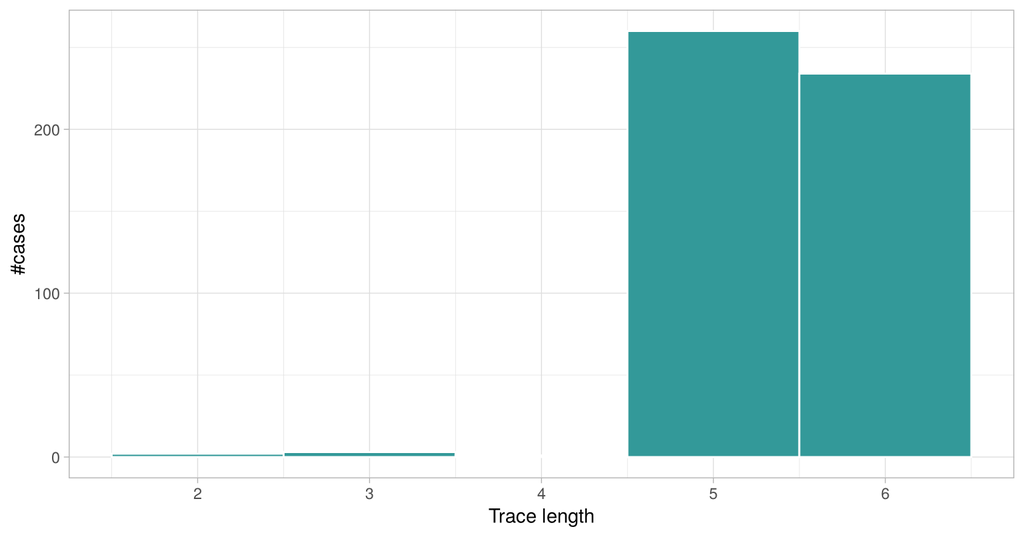

```r
patients %>% trace_length("log") %>% plot()
```

The median case has 5 activities. The few short traces (2–4) are patients whose journey hadn’t finished when the data was extracted, or data-quality issues worth investigating.

## B4. Process maps

```r
patients %>% process_map(frequency("absolute"))
```

[interactive chart not shown]

```r
patients %>% process_map(frequency("relative"))
```

[interactive chart not shown]

**The sheet’s question: what does 18.38% on Registration mean?** With `frequency("relative")` each node shows its share of all activity instances: 500 Registrations out of 2,721 instances = 18.38%. Each arc shows the proportion of the *from* activity’s departures that go to the *to* activity.

```r
500 / n_activity_instances(patients)
```

```
## [1] 0.183756
```

## B5. The process map is a first-order Markov model

Let’s compute the transition probabilities ourselves from the raw log, so the map is no longer a black box.

```r
ev <- as.data.frame(patients) %>%
  filter(registration_type == "start") %>%            # one row per activity instance
  arrange(patient, time)
seqs <- split(as.character(ev$handling), ev$patient)  # one trace per patient
pairs <- do.call(rbind, lapply(seqs, function(s) {
  s <- c("Start", s, "End")
  data.frame(from = head(s, -1), to = tail(s, -1))
}))
counts <- table(pairs$from, pairs$to)
counts
```

```
##
##                         Blood test Check-out Discuss Results End MRI SCAN
##   Blood test                     0         0               0   1      236
##   Check-out                      0         0               0 492        0
##   Discuss Results                0       492               0   3        0
##   MRI SCAN                       0         0             236   0        0
##   Registration                   0         0               0   0        0
##   Start                          0         0               0   0        0
##   Triage and Assessment        237         0               0   2        0
##   X-Ray                          0         0             259   2        0
##
##                         Registration Triage and Assessment X-Ray
##   Blood test                       0                     0     0
##   Check-out                        0                     0     0
##   Discuss Results                  0                     0     0
##   MRI SCAN                         0                     0     0
##   Registration                     0                   500     0
##   Start                          500                     0     0
##   Triage and Assessment            0                     0   261
##   X-Ray                            0                     0     0
```

```r
P <- prop.table(counts, margin = 1)                   # each row sums to 1: P(next | current)
round(P, 3)
```

```
##
##                         Blood test Check-out Discuss Results   End MRI SCAN
##   Blood test                 0.000     0.000           0.000 0.004    0.996
##   Check-out                  0.000     0.000           0.000 1.000    0.000
##   Discuss Results            0.000     0.994           0.000 0.006    0.000
##   MRI SCAN                   0.000     0.000           1.000 0.000    0.000
##   Registration               0.000     0.000           0.000 0.000    0.000
##   Start                      0.000     0.000           0.000 0.000    0.000
##   Triage and Assessment      0.474     0.000           0.000 0.004    0.000
##   X-Ray                      0.000     0.000           0.992 0.008    0.000
##
##                         Registration Triage and Assessment X-Ray
##   Blood test                   0.000                 0.000 0.000
##   Check-out                    0.000                 0.000 0.000
##   Discuss Results              0.000                 0.000 0.000
##   MRI SCAN                     0.000                 0.000 0.000
##   Registration                 0.000                 1.000 0.000
##   Start                        1.000                 0.000 0.000
##   Triage and Assessment        0.000                 0.000 0.522
##   X-Ray                        0.000                 0.000 0.000
```

Row “Triage and Assessment” says: after triage, 47.4% of patients go to Blood test and 52.2% to X-Ray. These are exactly the relative arc labels on the process map. The model is **first-order** because the next step depends only on the current activity, not on the history.

```r
# Use the Markov model to simulate new patient journeys
simulate_trace <- function(P) {
  s <- "Start"; out <- c()
  while (s != "End") { s <- sample(colnames(P), 1, prob = P[s, ]); if (s != "End") out <- c(out, s) }
  paste(out, collapse = " > ")
}
set.seed(1)
sort(table(replicate(1000, simulate_trace(P))), decreasing = TRUE)[1:3]
```

```
##
##                 Registration > Triage and Assessment > X-Ray > Discuss Results > Check-out
##                                                                                        546
## Registration > Triage and Assessment > Blood test > MRI SCAN > Discuss Results > Check-out
##                                                                                        439
##                             Registration > Triage and Assessment > X-Ray > Discuss Results
##                                                                                          5
```

## B6. Traces

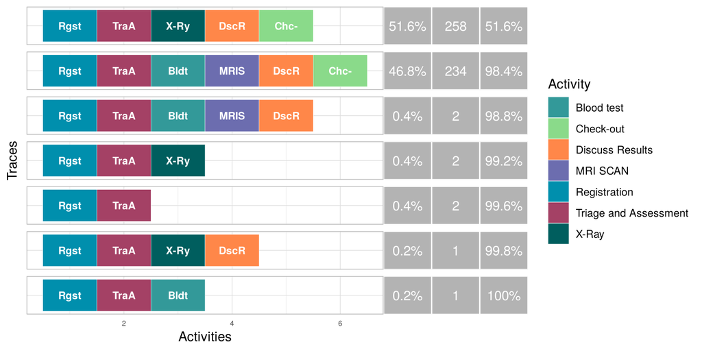

```r
patients %>% trace_explorer(n_traces = 10)
```

```r
tr <- sort(table(sapply(seqs, paste, collapse = " > ")), decreasing = TRUE)
data.frame(trace = names(tr), n = as.integer(tr), percent = round(100 * as.integer(tr) / length(seqs), 1))
```

```
##                                                                                        trace
## 1                 Registration > Triage and Assessment > X-Ray > Discuss Results > Check-out
## 2 Registration > Triage and Assessment > Blood test > MRI SCAN > Discuss Results > Check-out
## 3                                                       Registration > Triage and Assessment
## 4             Registration > Triage and Assessment > Blood test > MRI SCAN > Discuss Results
## 5                                               Registration > Triage and Assessment > X-Ray
## 6                                          Registration > Triage and Assessment > Blood test
## 7                             Registration > Triage and Assessment > X-Ray > Discuss Results
##     n percent
## 1 258    51.6
## 2 234    46.8
## 3   2     0.4
## 4   2     0.4
## 5   2     0.4
## 6   1     0.2
## 7   1     0.2
```

The most common trace: Registration → Triage and Assessment → X-Ray → Discuss Results → Check-out (258 patients, 51.6%). Together the top two traces cover 98.4% of patients.

## B7. Performance: where does the time go?

```r
patients %>% throughput_time("log", units = "days")          # first to last event per case
```

```
## # A tibble: 1 x 8
##   min           q1            median        mean        q3    max   st_dev iqr
##   <drtn>        <drtn>        <drtn>        <drtn>      <drt> <drt>  <dbl> <drt>
## 1 1.496088 days 4.313924 days 6.085509 days 6.676308 d~ 8.58~ 23.1~   3.22 4.27~
```

```r
patients %>% processing_time("activity", units = "hours")     # time spent inside each activity
```

```
## # A tibble: 7 x 11
##   handling              min    q1    mean  median q3    max   st_dev   iqr total
##   <fct>                 <drtn> <drt> <drt> <drtn> <drt> <drt>  <dbl> <dbl> <drt>
## 1 Registration          0.828~  2.0~  2.7~  2.71~  3.4~  5.6~  0.954 1.33  1376~
## 2 Triage and Assessment 5.868~ 11.3~ 13.1~ 13.34~ 15.0~ 18.8~  2.76  3.68  6552~
## 3 Discuss Results       1.333~  2.3~  2.7~  2.77~  3.2~  4.5~  0.628 0.906 1374~
## 4 Check-out             0.667~  1.6~  2.0~  2.07~  2.4~  3.8~  0.620 0.860 1014~
## 5 X-Ray                 2.294~  3.8~  4.8~  4.79~  5.6~  8.1~  1.28  1.76  1264~
## 6 Blood test            3.089~  4.7~  5.5~  5.46~  6.2~  8.1~  1.06  1.51  1311~
## 7 MRI SCAN              2.489~  3.6~  4.1~  4.09~  4.6~  5.9~  0.735 1.09   979~
## # i 1 more variable: relative_frequency <dbl>
```

```r
patients %>% process_map(performance(median, "hours"))        # median waiting time on each arc
```

[interactive chart not shown]

## B8. Filtering and conformance

```r
# Only patients who had an X-ray
xray <- patients %>% filter_activity_presence("X-Ray")
n_cases(xray)
```

```
## [1] 261
```

```r
# Conformance to a standard pathway: did each patient follow the X-ray route exactly?
standard <- "Registration > Triage and Assessment > X-Ray > Discuss Results > Check-out"
traces_chr <- sapply(seqs, paste, collapse = " > ")
table(conforms = traces_chr == standard)
```

```
## conforms
## FALSE  TRUE
##   242   258
```

```r
# Deviations among X-ray patients
table(traces_chr[grepl("X-Ray", traces_chr) & traces_chr != standard])
```

```
##
##                   Registration > Triage and Assessment > X-Ray
##                                                              2
## Registration > Triage and Assessment > X-Ray > Discuss Results
##                                                              1
```

## B9. Build your own event log

```r
project <- data.frame(
  case     = c(1, 1, 1, 1, 2, 2, 2, 2, 2, 3, 3, 3),
  activity = c("Plan", "Clean data", "Model", "Report",
               "Plan", "Clean data", "Model", "Fix leakage", "Report",
               "Plan", "Model", "Report"),
  time = as.POSIXct("2025-03-01 09:00") + c(0, 2, 5, 9, 0, 1, 3, 6, 10, 0, 4, 8) * 86400)
log <- simple_eventlog(project, case_id = "case", activity_id = "activity", timestamp = "time")
log
```

```
## # Log of 12 events consisting of:
## 3 traces
## 3 cases
## 12 instances of 5 activities
## 1 resource
## Events occurred from 2025-03-01 09:00:00 until 2025-03-11 09:00:00
##
## # Variables were mapped as follows:
## Case identifier:     case
## Activity identifier:     activity
## Resource identifier:     resource_id
## Activity instance identifier:    activity_instance_id
## Timestamp:           time
## Lifecycle transition:        lifecycle_id
##
## # A tibble: 12 x 7
##     case activity    time                resource_id activity_instance_id
##    <dbl> <chr>       <dttm>              <chr>                      <int>
##  1     1 Plan        2025-03-01 09:00:00 undefined                      1
##  2     1 Clean data  2025-03-03 09:00:00 undefined                      2
##  3     1 Model       2025-03-06 09:00:00 undefined                      3
##  4     1 Report      2025-03-10 09:00:00 undefined                      4
##  5     2 Plan        2025-03-01 09:00:00 undefined                      5
##  6     2 Clean data  2025-03-02 09:00:00 undefined                      6
##  7     2 Model       2025-03-04 09:00:00 undefined                      7
##  8     2 Fix leakage 2025-03-07 09:00:00 undefined                      8
##  9     2 Report      2025-03-11 09:00:00 undefined                      9
## 10     3 Plan        2025-03-01 09:00:00 undefined                     10
## 11     3 Model       2025-03-05 09:00:00 undefined                     11
## 12     3 Report      2025-03-09 09:00:00 undefined                     12
## # i 2 more variables: lifecycle_id <chr>, .order <int>
```

```r
log %>% process_map()
```

[interactive chart not shown]

```r
log %>% traces()
```

```
## # A tibble: 3 x 3
##   trace                                    absolute_frequency relative_frequency
##   <chr>                                                 <int>              <dbl>
## 1 Plan,Clean data,Model,Report                              1              0.333
## 2 Plan,Clean data,Model,Fix leakage,Report                  1              0.333
## 3 Plan,Model,Report                                         1              0.333
```

## B10. A larger real log

```r
sepsis                                    # 1,050 hospital cases with sepsis
```

```
## # Log of 15214 events consisting of:
## 846 traces
## 1050 cases
## 15214 instances of 16 activities
## 26 resources
## Events occurred from 2013-11-07 08:18:29 until 2015-06-05 12:25:11
##
## # Variables were mapped as follows:
## Case identifier:     case_id
## Activity identifier:     activity
## Resource identifier:     resource
## Activity instance identifier:    activity_instance_id
## Timestamp:           timestamp
## Lifecycle transition:        lifecycle
##
## # A tibble: 15,214 x 34
##    case_id activity  lifecycle resource timestamp             age   crp diagnose
##    <chr>   <fct>     <fct>     <fct>    <dttm>              <dbl> <dbl> <chr>
##  1 A       ER Regis~ complete  A        2014-10-22 11:15:41    85    NA A
##  2 A       Leucocyt~ complete  B        2014-10-22 11:27:00    NA    NA <NA>
##  3 A       CRP       complete  B        2014-10-22 11:27:00    NA   210 <NA>
##  4 A       LacticAc~ complete  B        2014-10-22 11:27:00    NA    NA <NA>
##  5 A       ER Triage complete  C        2014-10-22 11:33:37    NA    NA <NA>
##  6 A       ER Sepsi~ complete  A        2014-10-22 11:34:00    NA    NA <NA>
##  7 A       IV Liquid complete  A        2014-10-22 14:03:47    NA    NA <NA>
##  8 A       IV Antib~ complete  A        2014-10-22 14:03:47    NA    NA <NA>
##  9 A       Admissio~ complete  D        2014-10-22 14:13:19    NA    NA <NA>
## 10 A       CRP       complete  B        2014-10-24 09:00:00    NA  1090 <NA>
## # i 15,204 more rows
## # i 26 more variables: diagnosticartastrup <lgl>, diagnosticblood <lgl>,
## #   diagnosticecg <lgl>, diagnosticic <lgl>, diagnosticlacticacid <lgl>,
## #   diagnosticliquor <lgl>, diagnosticother <lgl>, diagnosticsputum <lgl>,
## #   diagnosticurinaryculture <lgl>, diagnosticurinarysediment <lgl>,
## #   diagnosticxthorax <lgl>, disfuncorg <lgl>, hypotensie <lgl>, hypoxie <lgl>,
## #   infectionsuspected <lgl>, infusion <lgl>, lacticacid <chr>, ...
```

```r
sepsis %>% n_traces()                     # very many distinct traces: real processes are messy
```

```
## [1] 846
```

```r
sepsis %>% activity_frequency("activity") %>% head(8)
```

```
## # A tibble: 8 x 3
##   activity         absolute relative
##   <fct>               <int>    <dbl>
## 1 Leucocytes           3383   0.222
## 2 CRP                  3262   0.214
## 3 LacticAcid           1466   0.0964
## 4 Admission NC         1182   0.0777
## 5 ER Triage            1053   0.0692
## 6 ER Registration      1050   0.0690
## 7 ER Sepsis Triage     1049   0.0689
## 8 IV Antibiotics        823   0.0541
```

```r
sepsis %>% filter_activity_frequency(percentage = 0.8) %>% process_map()   # most frequent 80% of activities
```

[interactive chart not shown]

**Ask:** `patients` has a handful of traces; `sepsis` has hundreds. What does that tell you about real hospital processes, and why do process miners filter to the most frequent activities before drawing a map?

# Summary

| Task | R (bupaR) |
| --- | --- |
| Inspect a log | `n_cases()`, `n_activities()`, `mapping()` |
| Activities | `activity_frequency("activity")`, `activity_presence()` |
| Traces | `trace_length("log")`, `traces()`, `trace_explorer(n_traces = 10)` |
| Process maps | `process_map(frequency("absolute" / "relative"))`, `process_map(performance(median, "hours"))` |
| Time | `throughput_time()`, `processing_time()` |
| Filter | `filter_activity_presence()`, `filter_activity_frequency()` |
| Build a log | `simple_eventlog(df, case_id, activity_id, timestamp)` |